# Regularisation Regression

We expect the models with increasing complexity to better fit the training data and result in lower residual (error) values. Though this leads to overfitting. Apart from this, **the size of coefficients increase exponentially with increase in model complexity**.

What does a large coefficient signify? It means that we’re putting a lot of emphasis on that feature, i.e. the particular feature is a good predictor for the outcome. When it becomes too large, the algorithm starts modelling intricate relations to estimate the output and ends up overfitting to the particular training data.

Thus, putting a constraint on the magnitude of coefficients can be a good idea to reduce model complexity.

### What is Regularization?

Regularization is a technique to discourage the complexity of the model. It does this by adding a “penalty” term to the best fit derived from the trained data, to achieve a lesser variance with the tested data and also restricts the influence of predictor variables over the output variable by compressing their coefficients.

A simple relation for linear regression looks like this.

$$ \hat{y_i} = \beta_0 + \sum_{j=1}^{p}{\beta_j x_{ij}}$$

where $\beta_j$ represents the coefficient estimates for different variables or predictors $(X)$

The fitting procedure involves a loss function (error function), known as **residual sum of squares** or **RSS**. The coefficients are chosen, such that they minimize this loss function.

This will adjust the coefficients based on your training data.

**Regularization works on assumption that smaller coefficients generate simpler model and thus helps avoid overfitting.**

There are two main regularization techniques, namely Ridge Regression and Lasso Regression. They both differ in the way they assign a penalty to the coefficients.

## Ridge Regression

Ridge regression performs ‘**L2 regularization**‘, i.e. **it adds a factor of sum of squares of coefficients in the optimization objective**. Thus, ridge regression optimizes the following:

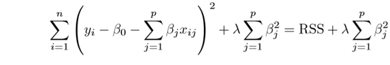

We have added the regularization term to the sum of squared differences between the actual value and predicted value. Now, the coefficients are estimated by minimizing this function. Regularization term keeps the coefficients small making the model simpler and avoiding overfitting.

**λ is the penalty term or regularization parameter which determines how much to penalizes the coefficients**. When λ is zero then the regularization term becomes zero. We are back to the original Loss function (i.e., RSS).

When λ is large, we penalizes the weights and they become close to zero. This results is a very simple model having a high bias or is underfitting.

**so what is the right value for λ ?**

It is somewhere in between 0 and a large value. we need to find an optimal value of λ so that the generalization error is small.A simple approach would be try different values of λ on a subsample of data, understand variability of the loss function and then use it on the entire dataset.

The increase in flexibility of a model is represented by increase in its coefficients, and if we want to minimize the above function, then these coefficients need to be small. This is how the Ridge regression technique prevents coefficients from rising too high.

Again, $\lambda$ is the tuning parameter that decides **how much we want to penalize** the flexibility of our model.

- $\lambda = 0$:

  The objective becomes same as simple linear regression. Ridge regression will produce the classical least square coefficients.
- $\lambda \to \infty$:

  The coefficients will approach zero. Why? Because of infinite weightage on square of coefficients, anything less than zero will make the objective infinite. In such as case, we get an intercept-only model.
- $ 0 < \lambda < \infty$

  The magnitude of $\lambda$ will decide the weightage given to different parts of objective. The coefficients will be somewhere between 0 and ones for simple linear regression.

Also, notice that we shrink the coefficients of each variable, except the intercept $\beta_0$

**Note that, in contrast to the ordinary least square regression, ridge regression is highly affected by the scale of the predictors. Therefore, it is better to standardize (i.e., scale) the predictors before applying the ridge regression**

Ridge regression shrinks the regression coefficients, so that variables, with minor contribution to the outcome, have their coefficients close to zero.

Ridge regression shrinks the coefficients towards zero, but it will not set any of them exactly to zero. The lasso regression is an alternative that overcomes this drawback.

## Lasso Regression

LASSO stands for Least Absolute Shrinkage and Selection Operator. Lasso regression performs **L1 regularization**, i.e. **it adds a factor of sum of absolute value of coefficients in the optimization objective**. Thus, lasso regression optimizes the following:

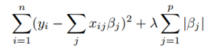

i.e., Residual Sum of Squares + λ * (Sum of the absolute value of the magnitude of coefficients)

Lasso is another variation, in which the above function is minimized. Its clear that this variation differs from ridge regression only in penalizing the high coefficients. It uses $|\beta_j|$ (modulus)instead of squares of β, as its penalty. In statistics, this is known as the L1 norm.

**Lasso can set some coefficients to zero, thus performing variable selection, while ridge regression cannot.**

In the case of lasso regression, the penalty has the effect of forcing some of the coefficient estimates, with a minor contribution to the model, to be exactly equal to zero. This means that, lasso can be also seen as an alternative to the subset selection methods for performing variable selection in order to reduce the complexity of the model.

One obvious advantage of lasso regression over ridge regression, is that it produces simpler and more interpretable models that incorporate only a reduced set of the predictors. However, neither ridge regression nor the lasso will universally dominate the other.

Generally, lasso might perform better in a situation where some of the predictors have large coefficients, and the remaining predictors have very small coefficients.

Ridge regression will perform better when the outcome is a function of many predictors, all with coefficients of roughly equal size.

There is also a combination of the above two called Elastic Net. This add regularization terms in the model which are combination of both L1 and L2 regularization. It can both shrink the coefficients as well as eliminate some of the insignificant coefficients.

**SUMMARY:**

Ridge Regression:

- Performs L2 regularization, i.e. adds penalty equivalent to square of the magnitude of coefficients
- Minimization objective = LS Obj + α * (sum of square of coefficients)

Lasso Regression:

- Performs L1 regularization, i.e. adds penalty equivalent to absolute value of the magnitude of coefficients
- Minimization objective = LS Obj + α * (sum of absolute value of coefficients)

Note that here ‘LS Obj’ refers to ‘least squares objective’, i.e. the linear regression objective without regularization and α is used in place of $\lambda$.

**Extra Reading:**

https://www.analyticsvidhya.com/blog/2016/01/ridge-lasso-regression-python-complete-tutorial/

### Regularisation example using Sklearn

#### Imports

```python
# Core libraries
import pandas as pd
import numpy as np

import matplotlib.pyplot as plt

# Sklearn processing
from sklearn.preprocessing import MinMaxScaler
from sklearn.model_selection import train_test_split


# Sklearn regression algorithms
from sklearn.linear_model import LinearRegression
from sklearn.linear_model import Lasso, Ridge

# Sklearn regression model evaluation functions
from sklearn.metrics import r2_score
```

#### Load data, split into X and y and scale data

```python
# Load the house prices data set
dataset = pd.read_csv("house_prices.csv")

# Split into X and y
y = dataset.SalesPrice
X = dataset.drop('SalesPrice', axis=1)
#X = X.loc[:, 'MS SubClass':'MS Zoning_RM']
X_dataset = X

# Rescale the input features
scaler = MinMaxScaler(feature_range=(0,1))
X = scaler.fit_transform(X)
```

```python
dataset.shape
```

```
(2930, 305)
```

```python
dataset.head()
```

|  | MS SubClass | Lot Frontage | Lot Area | Overall Qual | Overall Cond | Year Built | Year Remod/Add | Mas Vnr Area | BsmtFin SF 1 | BsmtFin SF 2 | ... | Sale Type_Oth | Sale Type_VWD | Sale Type_WD | Sale Condition_Abnorml | Sale Condition_AdjLand | Sale Condition_Alloca | Sale Condition_Family | Sale Condition_Normal | Sale Condition_Partial | SalesPrice |
| --- | --- | --- | --- | --- | --- | --- | --- | --- | --- | --- | --- | --- | --- | --- | --- | --- | --- | --- | --- | --- | --- |
| 0 | 20 | 141.0 | 31770 | 6 | 5 | 1960 | 1960 | 112.0 | 639.0 | 0.0 | ... | 0 | 0 | 1 | 0 | 0 | 0 | 0 | 1 | 0 | 215000 |
| 1 | 20 | 80.0 | 11622 | 5 | 6 | 1961 | 1961 | 0.0 | 468.0 | 144.0 | ... | 0 | 0 | 1 | 0 | 0 | 0 | 0 | 1 | 0 | 105000 |
| 2 | 20 | 81.0 | 14267 | 6 | 6 | 1958 | 1958 | 108.0 | 923.0 | 0.0 | ... | 0 | 0 | 1 | 0 | 0 | 0 | 0 | 1 | 0 | 172000 |
| 3 | 20 | 93.0 | 11160 | 7 | 5 | 1968 | 1968 | 0.0 | 1065.0 | 0.0 | ... | 0 | 0 | 1 | 0 | 0 | 0 | 0 | 1 | 0 | 244000 |
| 4 | 60 | 74.0 | 13830 | 5 | 5 | 1997 | 1998 | 0.0 | 791.0 | 0.0 | ... | 0 | 0 | 1 | 0 | 0 | 0 | 0 | 1 | 0 | 189900 |

5 rows × 305 columns

#### Split into train and test sets

```python
# Train test split
X_train, X_test, y_train, y_test = train_test_split(X, y, test_size = 0.33, random_state=7)
```

### Build and evaluate a linear regression model

```python
# Create model
model_lr = LinearRegression()

# Fit model
model_lr.fit(X_train, y_train)
predictions = model_lr.predict(X_train)
print("Train:", r2_score(y_train, predictions))

# Evaluate
predictions = model_lr.predict(X_test)
print("Test:", r2_score(y_test, predictions))
```

```
Train: 0.9383541186089979
Test: -2.0432057435846592e+17
```

Oh No !! Training score is very high, but test score is very low. We must have overfitting.

### Build and evaluate a ridge regression model

```python
# Create model
model_r = Ridge(alpha=2)

#Fit model
model_r.fit(X_train, y_train)
predictions = model_r.predict(X_train)
print("Train:", r2_score(y_train, predictions))

# Evaluate
predictions = model_r.predict(X_test)
print("Test:", r2_score(y_test, predictions))
```

```
Train: 0.9251913512103855
Test: 0.8800181582163078
```

### Build and evaluate a lasso regression model

```python
# Create model
model_l = Lasso(alpha=1)

# Fit model
model_l.fit(X_train, y_train)
predictions = model_l.predict(X_train)
print("Train:", r2_score(y_train, predictions))

# Evaluate
predictions = model_l.predict(X_test)
print("Test:", r2_score(y_test, predictions))
```

```
Train: 0.9381307141916388
Test: 0.8699407926873262
```